# Assignment 5

Pranav Kasela $846965$

# Solution of the problem

The objective of the assignment is to maximize the reward in following condition:

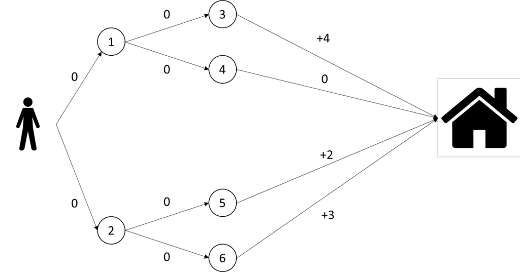

Representation of the problem

The initial polict $\pi_0$ is:

- $0 \to 2$
- $2 \to 5$
- $1 \to 4$

The state function of the nodes $3,4,5,6$, which remains costant will be not be calculated or written.

The state function for the initial policy is:

$$\begin{align*}
V^{\pi_0}(0)&=max\{0+\gamma \cdot 0, 0 + \gamma \cdot 2 \} = 2\\
V^{\pi_0}(1)&=max\{0 + \gamma \cdot 4 , 0 + \gamma \cdot 0 \} = 4\\
V^{\pi_0}(2)&=max\{0 + \gamma \cdot 2 , 0 + \gamma \cdot 3 \} = 3
\end{align*}$$

where the first argument indicates the path to the left and the second argument indicates the path to the right. $\gamma$, the discount factor, has been decided to be $=1$.

## Policy $\pi_1$

The new policy $\pi_1$ now is:

- $0 \to 2$
- $2 \to 6$
- $1 \to 3$

The state function in $\pi_1$ is:

$$\begin{align*}
V^{\pi_1}(0)&=max\{0+\gamma \cdot 4, 0 + \gamma \cdot 3 \} = 4\\
V^{\pi_1}(1)&=max\{0 + \gamma \cdot 4 , 0 + \gamma \cdot 0 \} = 4\\
V^{\pi_1}(2)&=max\{0 + \gamma \cdot 2 , 0 + \gamma \cdot 3 \} = 3
\end{align*}$$

## Policy $\pi_2$

The new policy derived from the state function is $\pi_2$:

- $0 \to 1$
- $2 \to 6$
- $1 \to 3$

Actually this is the best path, but to confirm the convergence the next step is needed.

It can be verified immediatly that the state function does not change and that $\pi_3 = \pi_2$, which is the condition for the convergence.